# Earthquake!

Harris Dupre

5/4/2020

### Introduction

The United States Geological Survey (USGS) is a US government agency that seeks to gather knowledge on natural phenomena, manage resources, and minimize damage from natural disasters.

Part of the agency’s mission is to track the location and magnitude of earthquakes all around the world. The USGS releases this data on their website, publicly available to download.  
The statistical analysis of earthquake data can provide insights into earthquake “hot zones,” areas that generally have a greater number of earthquakes or have more severe earthquakes. This is significant when designing buildings and infrastructure in an area – structures must be rated to withstand earthquakes that are likely to occur.

One of the fields in the data is “status,” which indicates whether or not the event’s data was reviewed by a human, or whether it was automatically recorded by the seismometer systems. Human input could cause changes in how a seismic event is recorded, thus impacting all subsequent analyses using that data.

Our research question will be, **"Is the recorded magnitude of an earthquake in our population impacted by whether or not the event data was reviewed by a human?**

## Data

#### Data Collection

The USGS employs a globally distributed network of earthquake sensors called the Global Seismographic Network to generate data on seismic activity. The position of these “seismometers” in relation to each other allows for the triangulation of the origin point (technically known as the hypocenter or focus) of an earthquake, both in geographic coordinates and depth in the Earth’s crust.

This data is then published to the USGS website (https://earthquake.usgs.gov/earthquakes/feed/v1.0/csv.php) in CSV format where it can be downloaded.

We will be limiting this data to earthquakes detected by the Southern California Seismic Network (locationSource == “ci”) as this will create consistency in the types of seismometers and magnitude algorithms used to generate the earthquake data.

#### Cases

Each case, or observation, is a single instance of seismic activity that was strong enough to be recorded by Southern California sensors (granted, the sensors are quite sensitive and can detect tremors that humans cannot perceive) from February 29th to March 29th, 2020.

It is also important to mention that this set of earthquakes has a maximum depth of 24km. Earthquakes with a depth of less than 60km are considered shallow. It is probably better to consider only shallow quakes in this study for completeness of data – seismometers cannot perceive lower magnitude earthquakes at extreme depths, so our data would show that there are no weak earthquakes below a depth of, for example, 300km which would throw off the statistics. The fact that the Southern California set is naturally limited to extremely shallow earthquakes means that we can get a complete picture of all the magnitudes in that depth range – even very weak earthquakes.

Finally, shallow earthquakes are much more interesting from a human perspective because they cause the most damage on the surface.

#### Variables

Magnitude and status are the two variables to be studied. Magnitude is a numerical/quantitative variable while status is categorical/qualitative. Magnitude is measured on a logarithmic scale, with a maximum severity of 10, while status can either be “reviewed” or “automatic” depending on whether or not a human reviewed the earthquake data or if it was automatically recorded by the seismometer systems.

#### Type of study

Although there are cases of human activity causing seismic events, generally we cannot have an impact the start or outcome of an earthquake. Also, we have not purposely reviewed some events and left some events as “automatic” for the purposes of an experiement. So, this is an observational study.

#### Scope of inference - generalizability

The population of interest here is shallow earthquakes in Southern California in March 2020. The sample is 200 earthquakes. This is a random sample so the findings of this analysis are generalizable to the population.

Potential sources of bias might be the range of equipment and techniques used to measure earthquakes. Some sensors on the seismographic network may be faulty. Earthquake magnitude is calculated using various algorithms that may yield different results for the same earthquake. The readings in this study come from a single, well-established and funded network, and the data is published by the USGS which seeks to reduce these potential sources of bias by comparing sensor readings and magnitude calculations from many sources and then publishes the data that it considers official for each seismic event.

#### Scope of inference - causality

The magnitude of an earthquake is impacted by a large range of variables: depth, location, soil conditions, tectonic plate position, etc. These variables cannot be held constant. Further, we are unable to randomly assign a set of circumstances to a sample of earthquakes before making our observations. For these reasons, causality cannot be established between the magnitude of an earthquake and its review status in this study.

## Exploratory Data Analysis

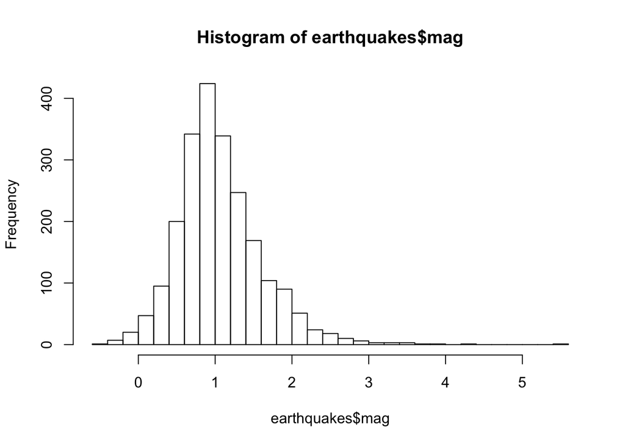

```r
# load data containing all earthquakes in March 2020
data <- read.csv("all_month.csv")
# filter out observations not of type "earthquake" since explosions, quarry blasting, and ice quakes are all perceived and recorded by seismometers
# filter out observations not of locationSource "ci" to limit us to data collected by the Southern California Seismic Network
earthquakes <- subset(data, type=="earthquake" & locationSource == "ci")

# determine if the population magnitude values are normally distributed
hist(earthquakes$mag, breaks = 25)
```

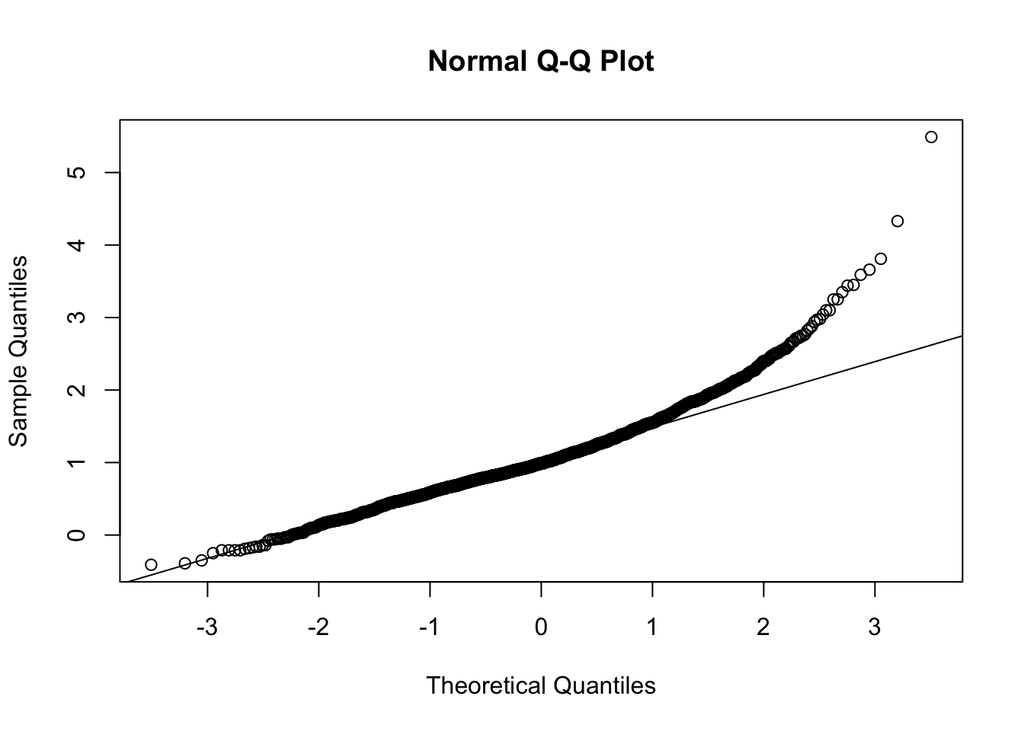

```r
qqnorm(earthquakes$mag)
qqline(earthquakes$mag)
```

```r
# take a sample of the population where n = 200
samp_earthquakes <- earthquakes[sample(nrow(earthquakes), 200), ]

reviewed <- subset(samp_earthquakes, status=="reviewed")
automatic <- subset(samp_earthquakes, status=="automatic")

#descriptive statistics on reviewed and automatic seismic events
summary(reviewed$mag)
```

```
##    Min. 1st Qu.  Median    Mean 3rd Qu.    Max.
##  -0.030   0.680   0.970   1.085   1.347   3.590
```

```r
summary(automatic$mag)
```

```
##    Min. 1st Qu.  Median    Mean 3rd Qu.    Max.
##   0.340   0.835   1.080   1.193   1.470   2.750
```

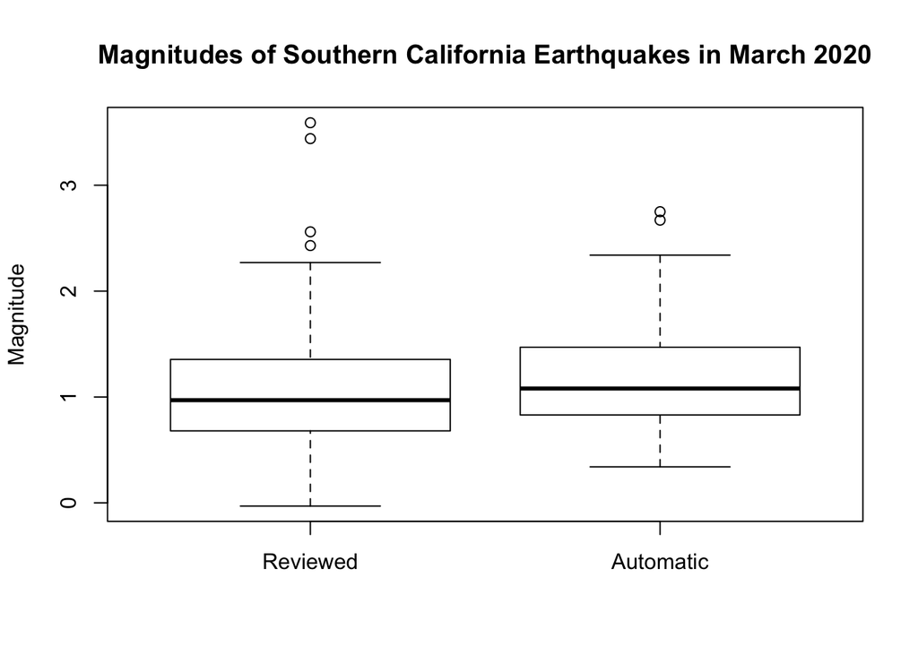

```r
# box plot
status <- c("Reviewed","Automatic")
boxplot(reviewed$mag,automatic$mag, names=status, main="Magnitudes of Southern California Earthquakes in March 2020", ylab="Magnitude")
```

#### Initial impressions

The population histogram appears to show near symmetry with some right-skew, which is confirmed by the qqnorm plot.

Based on the mean magnitude for each set, it appears that automatically recorded earthquakes tend to have a higher magnitude. This is in spite of reviewed events having a higher maxiumum magnitudes. It’s worth pointing out that each integer increase in magnitude represents a ten-fold increase in earthquake strength, so seemingly small decimal differences can translate to significantly more powerful events.

It makes sense that higher magnitude events are more often reviewed by a human since they are the events that are likely to cause damage or loss of life and are therefore more important from a social and scientific perspective.

## Inference

#### Conditions

- Sample size: The sample size of 200 observations is sufficiently large (n > 30).
- Independence: N < 10% of the population and sample was chosen randomly so the observations are independent of each other.
- Skew: The population distribution of magnitudes is nearly symmetric and not heavily skewed.

#### Theoretical Inference

```r
# hypothesis testing
ht_theo <- inference(samp_earthquakes$mag,x=samp_earthquakes$status,data=samp_earthquakes,type="ht", null=0, statistic="mean",method="theoretical",alternative="twosided")
```

```
## Response variable: numerical
## Explanatory variable: categorical (2 levels)
## n_automatic = 96, y_bar_automatic = 1.1932, s_automatic = 0.4834
## n_reviewed = 104, y_bar_reviewed = 1.0852, s_reviewed = 0.6262
## H0: mu_automatic =  mu_reviewed
## HA: mu_automatic != mu_reviewed
## t = 1.3715, df = 95
## p_value = 0.1734
```

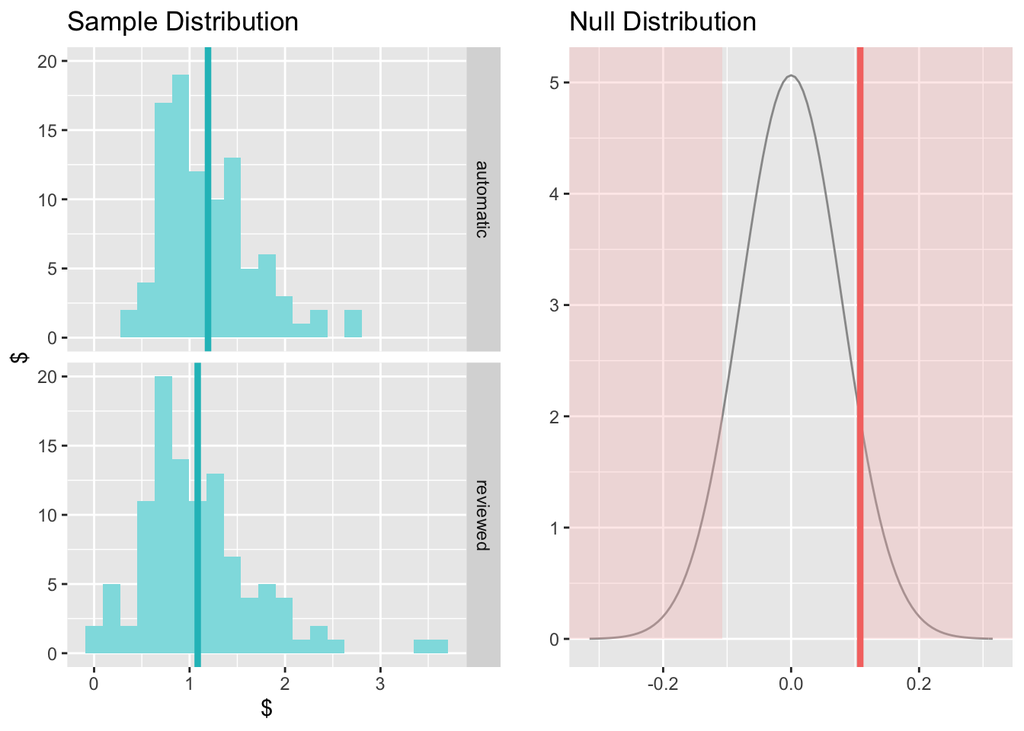

```r
# confidence interval
ci_theo <- inference(samp_earthquakes$mag,x=samp_earthquakes$status,data=samp_earthquakes,type="ci", null=0, statistic="mean",method="theoretical",alternative="twosided")
```

```
## Response variable: numerical, Explanatory variable: categorical (2 levels)
## n_automatic = 96, y_bar_automatic = 1.1932, s_automatic = 0.4834
## n_reviewed = 104, y_bar_reviewed = 1.0852, s_reviewed = 0.6262
## 95% CI (automatic - reviewed): (-0.0483 , 0.2644)
```

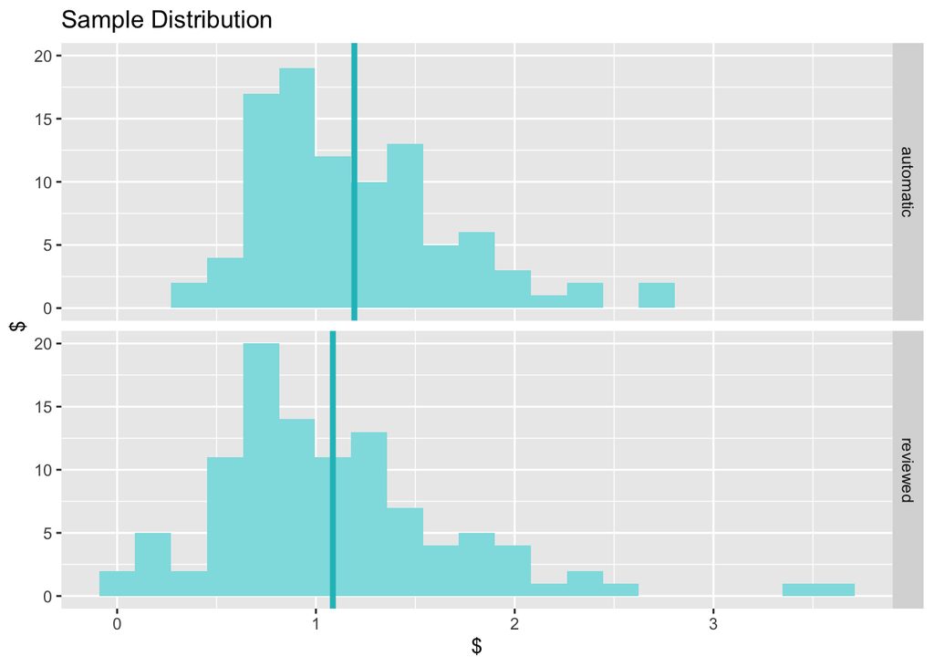

#### Simulation Inference

```r
# hypothesis testing
ht_sim <- inference(samp_earthquakes$mag,x=samp_earthquakes$status,data=samp_earthquakes,type="ht", null=0, statistic="mean",method="simulation",alternative="twosided")
```

[output not shown]

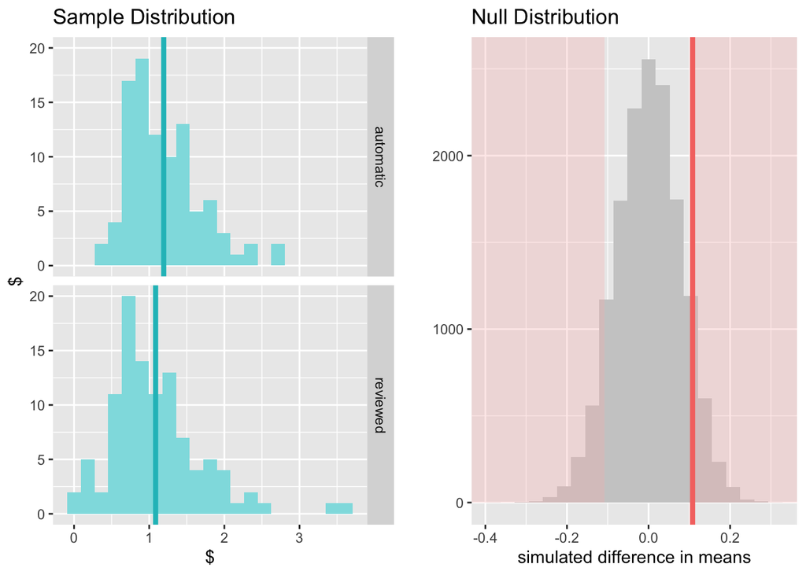

```r
# confidence interval
ci_sim <- inference(samp_earthquakes$mag,x=samp_earthquakes$status,data=samp_earthquakes,type="ci", null=0, statistic="mean",method="simulation",alternative="twosided", boot_method="se")
```

```
## Response variable: numerical, Explanatory variable: categorical (2 levels)
## n_automatic = 96, y_bar_automatic = 1.1932, s_automatic = 0.4834
## n_reviewed = 104, y_bar_reviewed = 1.0852, s_reviewed = 0.6262
## 95% CI (automatic - reviewed): (-0.0485 , 0.2646)
```

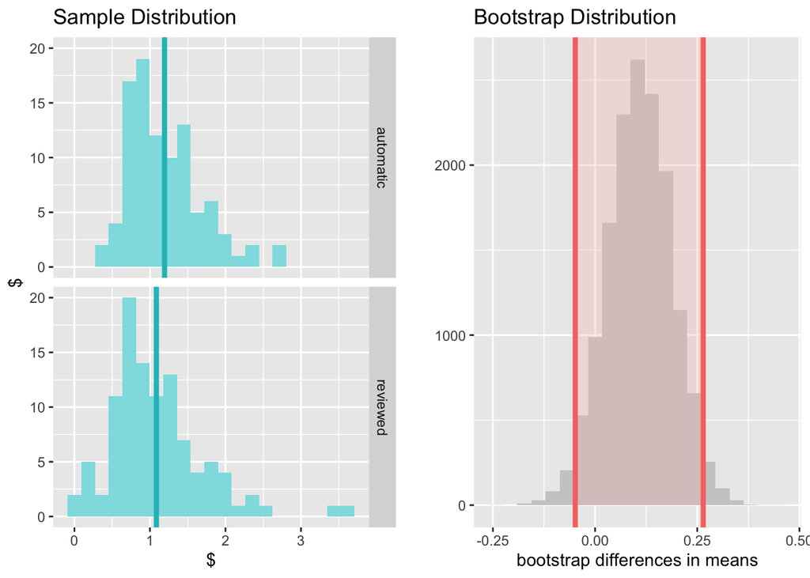

#### Methodology

Above we have performed hypothesis testing and confidence interval calculations on our sample to try to understand the relationship between the mean magnitude for reviewed and automatic status earthquakes.

As the data met the conditions for theoretical inference, we were able to run these test both for theoretical (central limit theorum) based calculations and simulation-based calculations.

The hypothesis being tested is whether the difference in the mean of the magnitude for reviewed and automatically recorded seismic events is statistically significant. The null hypothesis in this case would be that the “reviewed” status of an earthquake has no impact on the recorded magnitude.

The theoretical method uses the sample data, while the simulated method uses a simulated distribution.

## Conclusion

```r
# Result of theoretical hypothesis test
ht_theo$p_value
```

```
## [1] 0.1734376
```

```r
# Result of simulated hypothesis test
ht_sim$p_value
```

```
## [1] 0.1784
```

```r
# Result of theoretical 95% confidence interval
ci_theo$CI
```

```
## [1] -0.04834236  0.26441608
```

```r
# Result of simulated 95% confidence interval
ci_sim$CI
```

```
## [1] -0.04851436  0.26458808
```

#### Interpretation

The p-values for both the theoretical and simulated hypothesis tests are similar and well above 0.05, which would be the minimum we’d need to reject the null hypothesis.

**Therefore, we cannot reject the null hypothesis and cannot conclude from the data that the “reviewed” status of a shallow earthquake in March 2020 in Southern California has any impact on the recorded magnitude.**

#### Final Thoughts

I would hope that if there was a provable correlation between differences in magnitude based on the reviewed status of an event that the USGS would have found it already and taken steps to rectify it. In answering this reseach question I learned a great deal about both the organization and their research into seismic events, so I believe that such a question is relatively elementary compared to the rest of their work.

The data that’s generated with a seismic event offers numerous opportunities for further analysis, with the “magnitude” variable being of central importance.

One possibility could be to research the effect of the variable “magType,” representing the algorithm used to calculate the magnitude of a particular event, on recorded magnitude.

My original research question, which would have considered the depth and location of a population of earthquakes all over the world was a non-starter. As I mentioned earlier in this document, sensors become unable to perceive weak earthquakes at a certain depths, which makes it appear in the data as if there are only strong earthquakes at those depths. This skewed the data too severely to find any real linear trends.

I also learned about the inconsistency of earthquake “depth” data. According to the USGS (and this is apparent in the data), shallow earthquakes of uncertain depth are often recorded at a default value of 33km, while 5 or 10km is used for mid-continental areas and in mid-ocean ridges. This lack of accuracy, and the prevalence of identical default values, makes depth a difficult value from which to draw good conclusions.

By limiting my dataset to the single Southern California seismometer network, I avoided many of the issues of inconsistency that appeared in the overall set. The added benefit is that it’s much safer to draw conclusions about earthquakes when you are limited to one region, as the characteristics of seismic events are heavily dependent on geographic location.